# generalized linear mixed models

Ben Bolker

## (Generalized) linear mixed models

(G)LMMs: a statistical modeling framework incorporating:

- combinations of categorical and continuous predictors,  
  and interactions
- (some) non-Normal responses  
  (e.g. binomial, Poisson, and extensions)
- (some) nonlinearity  
  (e.g. logistic, exponential, hyperbolic)
- non-independent (grouped) data

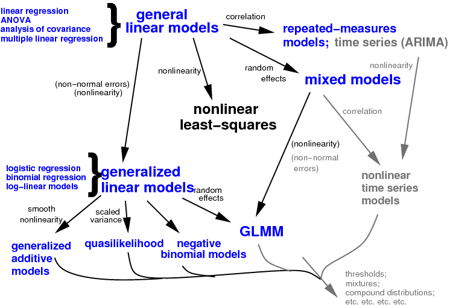

## Coral protection from seastars (*Culcita*) by symbionts (McKeon et al., 2012)

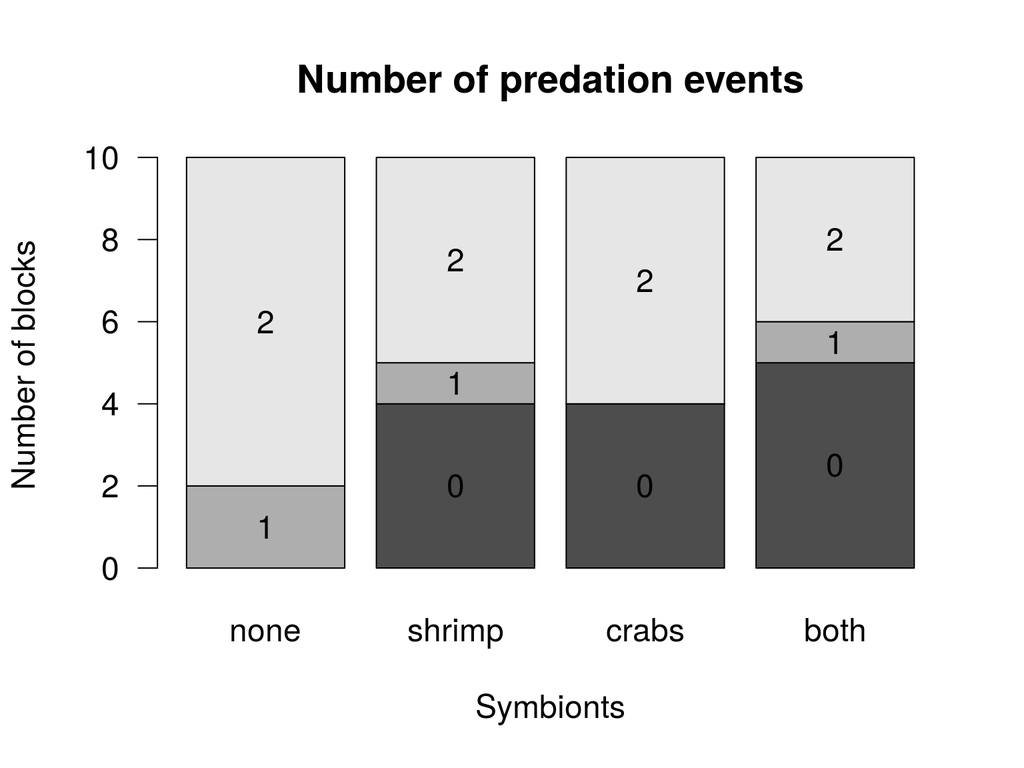

## Environmental stress: *Glycera* cell survival (D. Julian unpubl.)

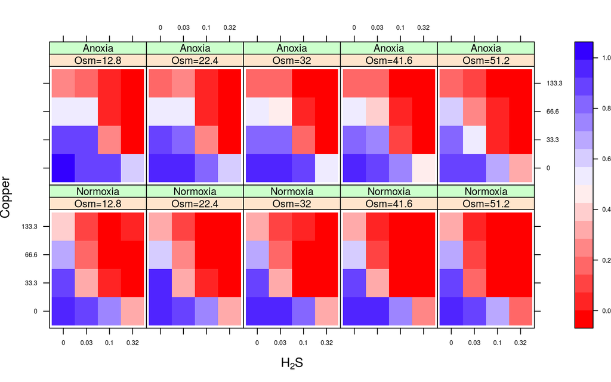

## *Arabidopsis* response to fertilization & herbivory (Banta et al., 2010)

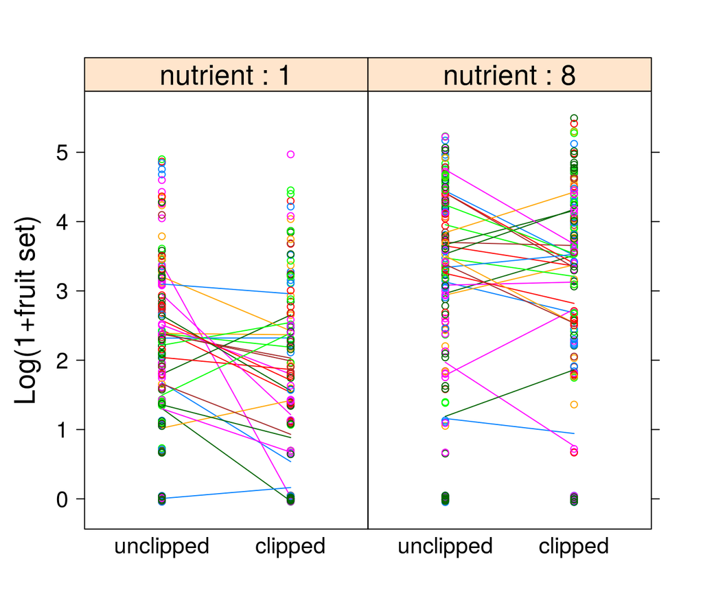

## Coral demography (J.-S. White unpubl.)

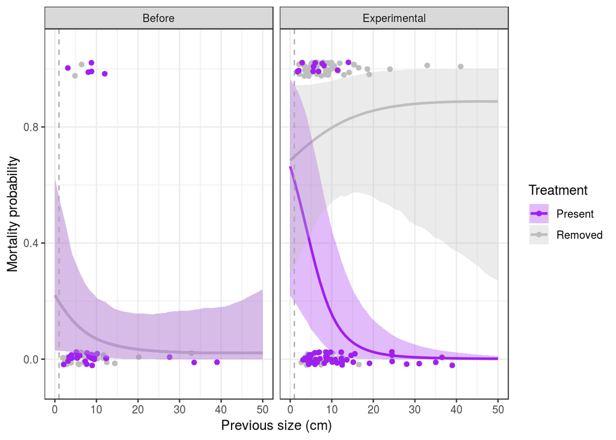

## Technical definition

$$\begin{split}
\underbrace{Y_i}_{\text{response}} & \sim \overbrace{\text{Distr}}^{\substack{\text{conditional} \\ \text{distribution}}}(\underbrace{g^{-1}(\eta_i)}_{\substack{\text{inverse} \\ \text{link} \\ \text{function}}},\underbrace{\phi}_{\substack{\text{scale} \\ \text{parameter}}}) \\
\underbrace{\boldsymbol \eta}_{\substack{\text{linear} \\ \text{predictor}}} &
=
\underbrace{\boldsymbol X \boldsymbol \beta}_{\substack{\text{fixed} \\ \text{effects}}} +
\underbrace{\boldsymbol Z \boldsymbol b}_{\substack{\text{random} \\ \text{effects}}}
\\
\underbrace{\boldsymbol b}_{\substack{\text{conditional} \\ \text{modes}}} &
\sim \text{MVN}(\boldsymbol 0, \underbrace{\Sigma(\boldsymbol \theta)}_{\substack{\text{variance-} \\ \text{covariance} \\ \text{matrix}}})
\end{split}$$

## What are random effects?

A method for …

- accounting for among-individual, within-block correlation
- compromising between  
  *complete pooling* (no among-block variance)  
  and *fixed effects* (large among-block variance)
- handling levels selected at random from a larger population
- sharing information among levels (*shrinkage estimation*)
- estimating variability among levels
- allowing predictions for unmeasured levels

## Random-effect myths

- levels of random effects must always be sampled at random
- a complete sample cannot be treated as a random effect
- random effects are always a *nuisance variable*
- nothing can be said about the predictions of a random effect
- you should always use a random effect no matter how few levels you have

## Reasons for random effects (inferential/philosophical)

- **don’t** want to
  - test hypotheses about differences between responses at particular levels of the grouping variable;
- **do** want to
  - quantify variation among groups
  - make predictions about unobserved groups
- have levels that are randomly sampled from/representative of a larger population (*exchangeable*)

## Reasons for random effects (practical)

- want to combine information across groups
- have variation in information per level (number of samples or noisiness);
- have a categorical predictor that is a nuisance variable (i.e., it is not of direct interest, but should be controlled for).
- have more than 5-6 groups, or regularizing/using priors (otherwise, use fixed)

See also Crawley (2002); Gelman (2005)

## Avoiding MM

- average: for *nested* LMMs (when uninterested in within-group variation) (Murtaugh, 2007)
- use fixed effects (or two-stage models) instead of random effects when (1) samples per block are large (shrinkage will be unimportant) or (2) number of samples is small (you will save few degrees of freedom, and variance estimates are likely to be bad anyway)

# Estimation

## Maximum likelihood estimation

- Best fit is a compromise between two components  
  (consistency of data with fixed effects and conditional modes; consistency of random effect with RE distribution)
  - Goodness-of-fit *integrates* over conditional modes

## …

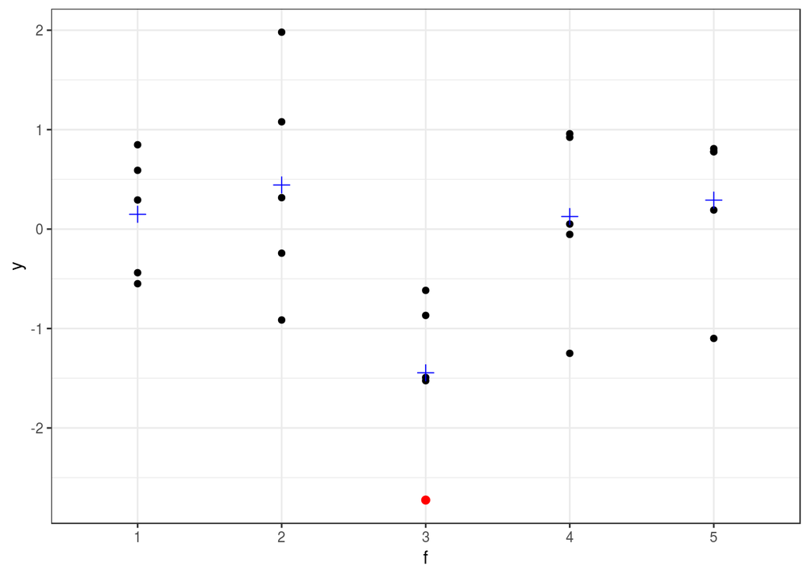

## Shrinkage: *Arabidopsis* conditional modes

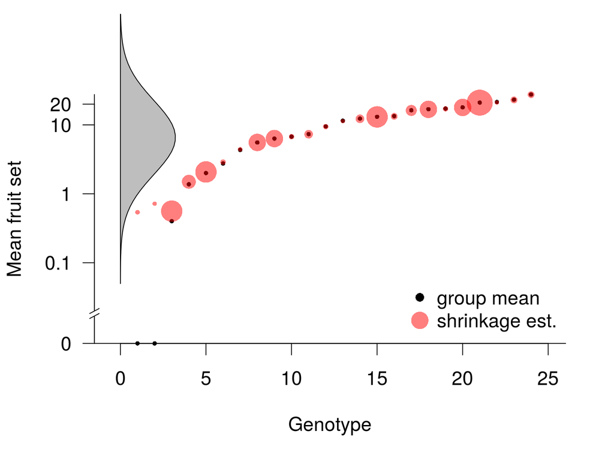

## Shrinkage in a random-slopes model

From Christophe Lalanne, see [here](https://stats.stackexchange.com/questions/51186/what-would-be-an-illustrative-picture-for-linear-mixed-models) and [here](https://gist.github.com/chlalanne/5074855):

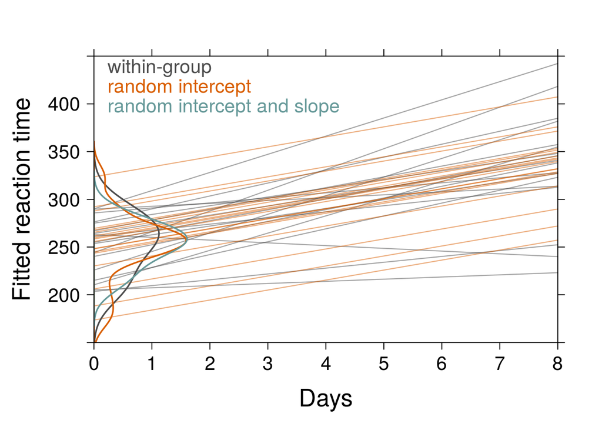

## Estimation methods

- deterministic
  - various approximate integrals (Breslow, 2004)
  - penalized quasi-likelihood, Laplace, Gauss-Hermite quadrature, … (Biswas, 2015);  
    best methods needed for large variance, small clusters
  - flexibility and speed vs. accuracy
- stochastic
- stochastic (Monte Carlo): frequentist and Bayesian
  - (Booth & Hobert, 1999; Ponciano et al., 2009; Sung & Geyer, 2007)
  - usually slower but flexible and accurate

## Estimation: *Culcita* (McKeon et al., 2012)

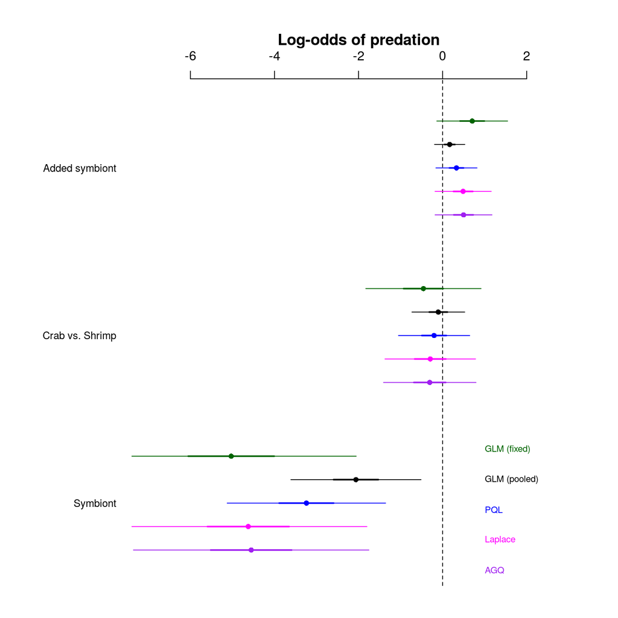

# Inference

## Wald tests

- typical results of `summary`
- exact for ANOVA, regression:  
  approximation for GLM(M)s
- fast
- approximation is sometimes awful (Hauck-Donner effect)

## Likelihood ratio tests

- better than Wald, but still have two problems:
  - “denominator degrees of freedom” (when estimating scale)
  - for GLMMs, distributions are approximate anyway (Bartlett corrections)
  - Kenward-Roger correction? (Stroup, 2014)
- Profile confidence intervals: expensive/fragile

## p-values choices?

- guess from classic design (R code)
- conservative: take minimum number of groups - 1
- Satterthwaite/Kenward-Roger (`lmerTest`, LMMs only)
- parametric bootstrap (`pbkrtest`)

## Parametric bootstrapping

- fit null model to data
- simulate “data” from null model
- fit null and working model, compute likelihood difference
- repeat to estimate null distribution
- should be OK but ??? not well tested  
  (assumes estimated parameters are “sufficiently” good)

## Bayesian inference

- If we have a good sample from the posterior distribution (Markov chains have converged etc. etc.) we get most of the inferences we want for free by summarizing the marginal posteriors
- *post hoc* Bayesian methods: use deterministic/frequentist methods to find the maximum, then sample around it

# Challenges & open questions

## On beyond `lme4`

- `glmmTMB`: zero-inflated and other distributions
- `brms`,`rstanarm`: interfaces to Stan
- `INLA`: spatial and temporal correlations
- [rethinking package](https://github.com/rmcelreath/rethinking)

## Toolboxes

- JAGS (R: `rjags`, `r2jags`)
- TensorFlow (R: `greta`)
- NIMBLE
- Stan (R: `rstan`)
- TMB (R: `TMB`)

## On beyond R

- Julia: MixedModels package
- SAS: PROC MIXED, NLMIXED
- AS-REML
- Stata (GLLAMM, xtmelogit)
- HLM, MLWiN

## Challenges

- Small clusters: need AGQ/MCMC
- Small numbers of clusters: need finite-size corrections (KR/PB/MCMC)
- Small data sets: issues with *singular* fits  
  (Barr et al., 2013) vs. (Bates et al., 2015)
- Big data: speed!
- Model diagnosis
- Confidence intervals accounting for uncertainty in variances

## Spatial and temporal correlations

- Sometimes blocking takes care of non-independence …
- but sometimes there is temporal or spatial correlation *within* blocks
- … also phylogenetic … (Ives & Zhu, 2006)
- “G-side” vs. “R-side” effects
- tricky to implement for GLMMs, but new possibilities on the horizon (Rousset & Ferdy, 2014; Rue et al., 2009); https://github.com/stevencarlislewalker/lme4ord

## Next steps

- Complex random effects:  
  regularization, model selection, penalized methods (lasso/fence)
- Flexible correlation and variance structures
- Flexible/nonparametric random effects distributions
- hybrid & improved MCMC methods
- *Reliable* assessment of out-of-sample performance
- http://ms.mcmaster.ca/~bolker/misc/private/14-Fox-Chap13.pdf
- https://bbolker.github.io/mixedmodels-misc/ecostats_chap.html
- B. M. Bolker (2015)

Banta, J. A., Stevens, M. H. H., & Pigliucci, M. (2010). A comprehensive test of the ’limiting resources’ framework applied to plant tolerance to apical meristem damage. *Oikos*, *119*(2), 359–369. http://doi.org/10.1111/j.1600-0706.2009.17726.x

Barr, D. J., Levy, R., Scheepers, C., & Tily, H. J. (2013). Random effects structure for confirmatory hypothesis testing: Keep it maximal. *Journal of Memory and Language*, *68*(3), 255–278. http://doi.org/10.1016/j.jml.2012.11.001

Bates, D., Kliegl, R., Vasishth, S., & Baayen, H. (2015). Parsimonious Mixed Models. *ArXiv:1506.04967 [Stat]*. Retrieved from http://arxiv.org/abs/1506.04967

Biswas, K. (2015). *Performances of different estimation methods for generalized linear mixed models* (Master’s thesis). McMaster University. Retrieved from https://macsphere.mcmaster.ca/bitstream/11375/17272/2/M.Sc_Thesis_final_Keya_Biswas.pdf

Bolker, B. M. (2015). Linear and generalized linear mixed models. In G. A. Fox, S. Negrete-Yankelevich, & V. J. Sosa (Eds.), *Ecological statistics: Contemporary theory and application*. Oxford University Press.

Booth, J. G., & Hobert, J. P. (1999). Maximizing generalized linear mixed model likelihoods with an automated Monte Carlo EM algorithm. *Journal of the Royal Statistical Society. Series B*, *61*(1), 265–285. http://doi.org/10.1111/1467-9868.00176

Breslow, N. E. (2004). Whither PQL? In D. Y. Lin & P. J. Heagerty (Eds.), *Proceedings of the second seattle symposium in biostatistics: Analysis of correlated data* (pp. 1–22). Springer.

Crawley, M. J. (2002). *Statistical computing: An introduction to data analysis using S-PLUS*. John Wiley & Sons.

Gelman, A. (2005). Analysis of variance: Why it is more important than ever. *Annals of Statistics*, *33*(1), 1–53. http://doi.org/doi:10.1214/009053604000001048

Ives, A. R., & Zhu, J. (2006). Statistics for correlated data: Phylogenies, space, and time. *Ecological Applications*, *16*(1), 20–32. Retrieved from http://www.esajournals.org/doi/pdf/10.1890/04-0702

McKeon, C. S., Stier, A., McIlroy, S., & Bolker, B. (2012). Multiple defender effects: Synergistic coral defense by mutualist crustaceans. *Oecologia*, *169*(4), 1095–1103. http://doi.org/10.1007/s00442-012-2275-2

Murtaugh, P. A. (2007). Simplicity and complexity in ecological data analysis. *Ecology*, *88*(1), 56–62. Retrieved from http://www.esajournals.org/doi/abs/10.1890/0012-9658%282007%2988%5B56%3ASACIED%5D2.0.CO%3B2

Ponciano, J. M., Taper, M. L., Dennis, B., & Lele, S. R. (2009). Hierarchical models in ecology: Confidence intervals, hypothesis testing, and model selection using data cloning. *Ecology*, *90*(2), 356–362. Retrieved from http://www.jstor.org/stable/27650990

Rousset, F., & Ferdy, J.-B. (2014). Testing environmental and genetic effects in the presence of spatial autocorrelation. *Ecography*, no–no. http://doi.org/10.1111/ecog.00566

Rue, H., Martino, S., & Chopin, N. (2009). Gaussian models using integrated nested Laplace approximations (with discussion). *Journal of the Royal Statistical Society, Series B*, *71*(2), 319–392.

Stroup, W. W. (2014). Rethinking the analysis of non-normal data in plant and soil science. *Agronomy Journal*, *106*, 1–17. http://doi.org/10.2134/agronj2013.0342

Sung, Y. J., & Geyer, C. J. (2007). Monte Carlo likelihood inference for missing data models. *The Annals of Statistics*, *35*(3), 990–1011. http://doi.org/10.1214/009053606000001389